# Part I - (Dataset Exploration Title)

## Multivariate Exploration

[output not shown]

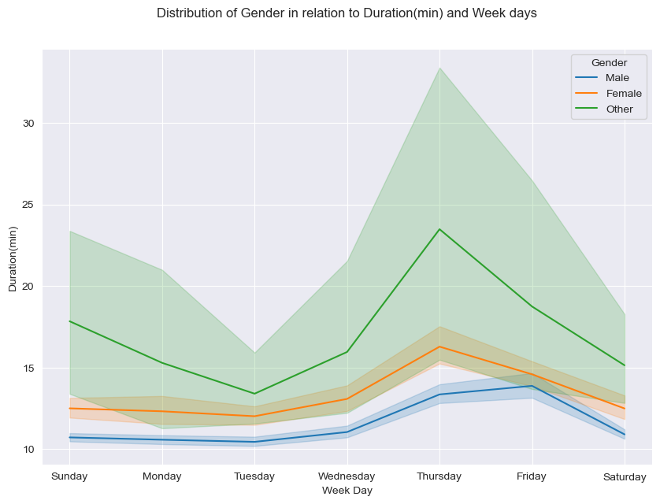

```python
sb.set_style('darkgrid')
fig,ax= plt.subplots(figsize=(10,7), dpi=100)
g=sb.lineplot(data=df, x='start_day',y='duration_min', hue='member_gender',hue_order=['Male','Female','Other'])
g.set_title('Distribution of Gender in relation to Duration(min) and Week days', y=1.06)
g.set(ylabel='Duration(min)', xlabel='Week Day')
plt.legend(title='Gender')
ax.set_xticklabels(day_order)
```

Other has an higher average ride duration(min) compare to the other gender

```python
#create  age intervals of 10
data= df.dropna(subset=['age_diff']).copy()
data['age_int']= ((data['age_diff']//10)*10).astype(int)
```

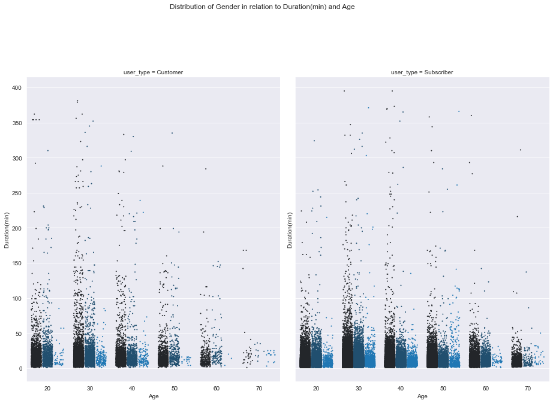

```python
g=sb.FacetGrid(data=data.query('duration_min<400 and age_diff<80'), col='user_type')
g.map(sb.stripplot, 'age_int','duration_min','member_gender', size=2,jitter=0.35,dodge=True)
g.fig.suptitle('Distribution of Gender in relation to Duration(min) and Age', y=1.06)
g.set(ylabel='Duration(min)', xlabel='Age')

g.fig.set_size_inches(14,10)
```

There isnt any significant difference between the gender disribtuion in relation to ride duration and age

```
No handles with labels found to put in legend.
```

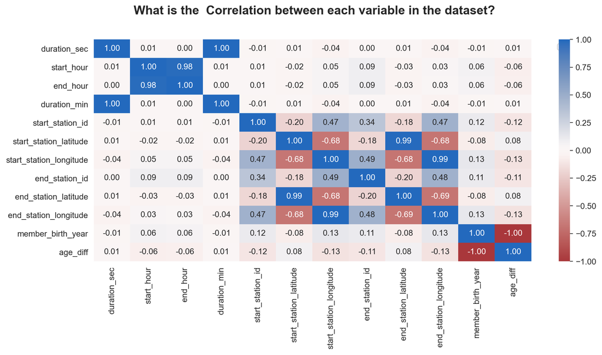

```python
#checking for any correllation that exists between all parameters in the dataset


plt.figure(figsize = (12,5), dpi = 200)
sb.heatmap(df.corr(), annot = True, fmt = '.2f', cmap = 'vlag_r', center = 0)
plt.title(" What is the  Correlation between each variable in the dataset?", y=1.09, fontsize=15, weight='bold')
plt.xticks(rotation = 90)
plt.legend(bbox_to_anchor=(1.05, 1), loc='upper left')
plt.show()
```

- There is no Correlation for any variable with time ( duration sec /minutes/hours)
- There is a weak Correlation between start_station_id with start_station_longitude and end_station_longitude , so we can say that the station location is a good factor.
- There is a strong Correlation between start station longitude and end_station longitude.

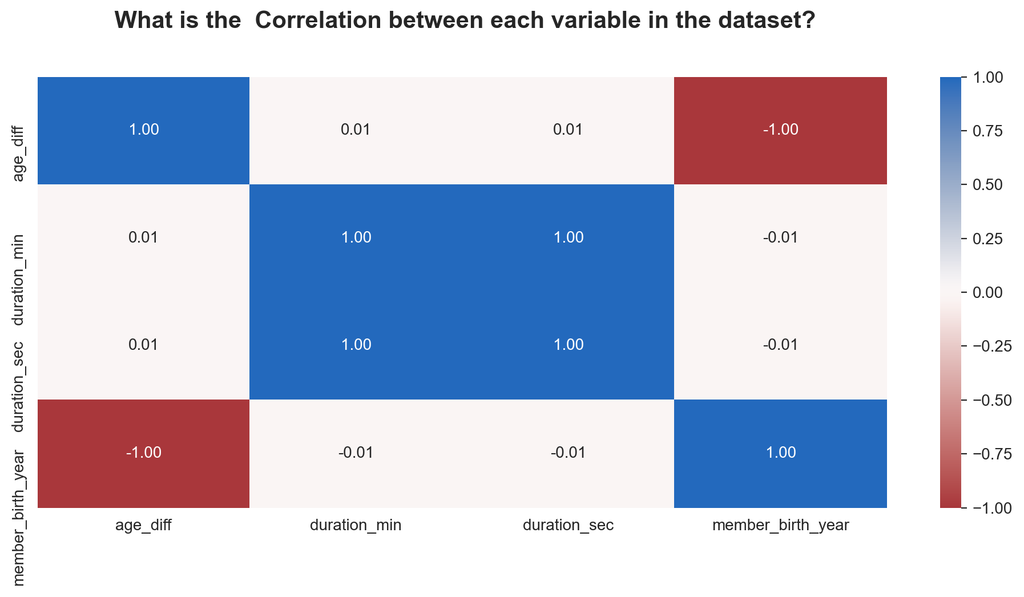

```python
data_stat = ['age_diff', 'duration_min',"duration_sec", "member_birth_year"]
plt.figure(figsize = (12,5), dpi = 200)

sb.heatmap(df[data_stat].corr(), annot = True, fmt = '.2f', cmap = 'vlag_r', center = 0)
plt.title(" What is the  Correlation between each variable in the dataset?", y=1.09, fontsize=15, weight='bold');
```

- There is no Correlation for any variable with time ( duration sec /minutes)
- There is a negative Correlation between member_birth_year and age which normal.

## Conclusion

According to the exploratory analysis that i have been able to visualized above, the following were observed;

- The average ride duration(secs) and median ride duration(secs) for the users is approximately 704 secs and 510 secs respectively
- There seem to be an uptrend in the number of riders starting out as the day goes by , but peak hours are 8 in the morning and 5 at night.
- Average rider's age is 36 years old
- Majority of the users are male, surmounting to approximately 75% of the total population
- Weekends are less busier than the rest of the week days
- Only a few users are participans of the bike share program
- Averagely, customers tends to spend more time riding compare to subscribers.
- This is quite surprising, Other and Female ride longer than male on an average.
- Male has an higher population using the services all week long, this is not suprising as they make up 75% of the entire users.

## Limitations

Missing values in the dataset

```python
df.to_csv('ford Gobike.csv')
```